# Reporte investigación

Ignacio Becker Bozo

04 July, 2020

## Introducción

En base a las constantes problemáticas de inserción laboral juvenil en las últimas décadas (CEPAL/OIJ, 2004; CEPAL/OIT, 2017), además de una subutilización de las fuentes de datos disponibles para medir sus condiciones, el presente proyecto busca aportar en una cuantificación de este fenómeno, mediante el uso de la Encuesta Nacional de Empleo del Instituto Nacional de Estadísticas.

Los procesos que reestructuraron la organización del empleo a mediados de siglo XX, relacionados a los mecanismos de flexibilización de los mercados laborales, junto a la precarización de la fuerza de trabajo, han orquestado novedosos mecanismos de empleo y contratación, basados en los contratos temporales, las jornadas parciales, la tercerización productiva -como la subcontratación-, entre otros dispositivos propios del empleo atípico (Neffa, 2008; Stecher & Sisto, 2019), que han debilitado aún más el empleo, impidiendo la generación de vínculos estables, protegidos y seguros para la integración social (Kaztman, 2001).

Este desarrollo, sin embargo, no afecta a todos los grupos sociales en la misma medida: el aumento de la flexibilidad supone una desregulación dirigida, alterando y reformando en primera instancia los márgenes del empleo (Atkinson, 1984), para luego ampliarse al resto de la fuerza de trabajo (O’Reilly et al., 2015). Los mismos autores señalan que este proceso ha promovido la segmentación del mercado laboral, llevándose la carga flexibilizadora aquellos empleados que son considerados atípicos, o al margen del empleo formal. Varios autores dan cuenta cómo la población joven es aquella que sufre estas condiciones en mayor medida (Furlong, 1990; Jacinto, 2006; O’Reilly et al., 2015; Weller, 2007), en el denominado mercado laboral juvenil (o *Youth Labor Market* [YLM], por su origen británico), el cual discute si estas condiciones son propias de la juventud, o se debe a situaciones de paso hacia el ingreso al mercado laboral (Ashton et al., 1990).

# Objetivos proyecto

En este sentido, y dado el carácter acotado del presente proyecto (el cual consta de solo un semestre), es que en el presente escrito se propone los siguientes objetivos, entendiendo los procesos de reestructuración y flexibilización de la fuerza de trabajo juvenil en los últimos años.

## Objetivo general

Caracterizar la temporalidad contractual de la población joven en Chile en base al trimestre marzo-abril-mayo 2019 de la Encuesta Nacional de Empleo.

## Objetivos específicos

- Describir la temporalidad contractual de las y los jóvenes asalariados en Chile, según variables sociodemográficas (como sexo, edad, región de residencia) y educativa.
- Identificar la temporalidad de la ocupación según las ramas de empleo de la población joven ocupada.
- Caracterizar la posesión de contrato por variables sociodemográficas.

# Resultados

A nivel de descriptivos preliminares, las variables a considerar son las siguientes:

[output not shown]

## Por tipo de contrato

```
## ### Cross-Tabulation, Column Proportions
## #### t_con * sexo
## **Data Frame:** ene
##
## |            |      |                   |                   |                    |
## |-----------:|-----:|------------------:|------------------:|-------------------:|
## |            | sexo |            Hombre |             Mujer |              Total |
## |      t_con |      |                   |                   |                    |
## |   Definido |      | 317311.6 ( 37.1%) | 256264.6 ( 36.3%) |  573576.2 ( 36.7%) |
## | Indefinido |      | 538082.6 ( 62.9%) | 449851.4 ( 63.7%) |  987934.0 ( 63.3%) |
## |      Total |      | 855394.2 (100.0%) | 706116.0 (100.0%) | 1561510.2 (100.0%) |
```

```
## Cross-Tabulation, Column Proportions
## t_con * tramo_etario
## Data Frame: ene
##
## ------------ -------------- ------------------ ------------------- ------------------- --------------------
##                tramo_etario              15-19               20-24               25-29                Total
##        t_con
##     Definido                  40240.9 ( 54.0%)   214195.2 ( 39.8%)   319140.2 ( 33.6%)    573576.2 ( 36.7%)
##   Indefinido                  34336.1 ( 46.0%)   324195.1 ( 60.2%)   629402.8 ( 66.4%)    987934.0 ( 63.3%)
##        Total                  74576.9 (100.0%)   538390.3 (100.0%)   948543.0 (100.0%)   1561510.2 (100.0%)
## ------------ -------------- ------------------ ------------------- ------------------- --------------------
```

```
## Cross-Tabulation, Column Proportions
## t_con * rama
## Data Frame: ene
##
## ------------ ------ ------------------ ------------------- -------------------- --------------------
##                rama           Primario          Secundario            Terciario                Total
##        t_con
##     Definido          59365.1 ( 65.7%)   141372.4 ( 44.3%)    372838.7 ( 32.4%)    573576.2 ( 36.7%)
##   Indefinido          30952.4 ( 34.3%)   177448.7 ( 55.7%)    779532.9 ( 67.6%)    987934.0 ( 63.3%)
##        Total          90317.6 (100.0%)   318821.1 (100.0%)   1152371.6 (100.0%)   1561510.2 (100.0%)
## ------------ ------ ------------------ ------------------- -------------------- --------------------
```

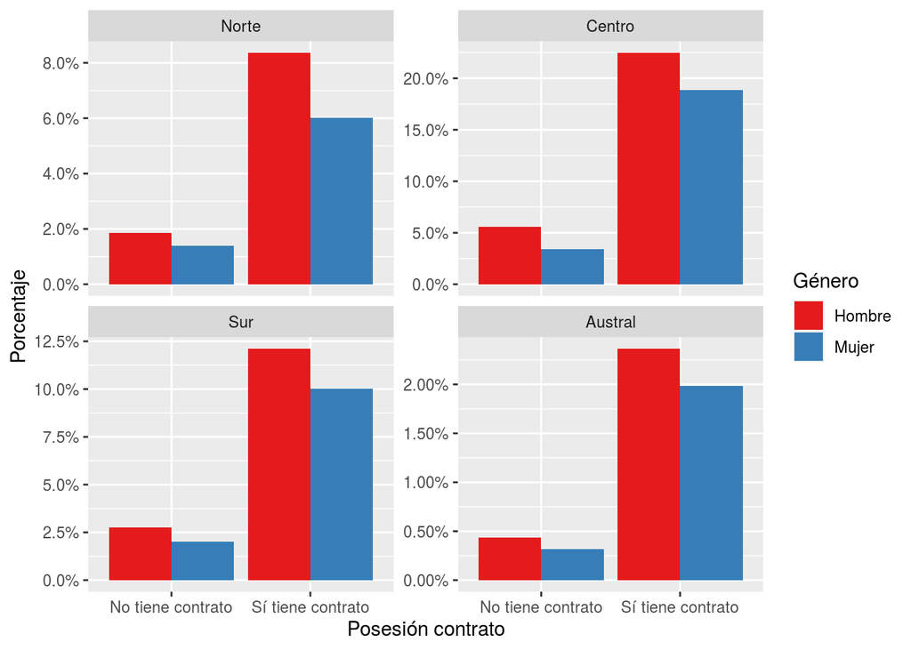

# Referencias

Ashton, D., Maguire, M., & Spilsbury, M. (1990). *Restructuring the labour market: The implications for youth*. Springer.

Atkinson, J. (1984). Manpower strategies for flexible organisations. *Personnel Management*, *16*(8), 28–31.

CEPAL/OIJ. (2004). *La juventud en Iberoamérica: Tendencias y urgencias*.

CEPAL/OIT. (2017). *Employment Situation in Latin America and the Caribbean: The transition of young people from school to the labour market* (Nos. 17; p. 38). https://repositorio.cepal.org//handle/11362/42251

Furlong, A. (1990). Labour market segmentation and the age structuring of employment opportunities for young people. *Work, Employment and Society*, *4*(2), 253–269.

Jacinto, C. (2006). Estrategias sistémicas y subjetivas de transición laboral de los jóvenes en Argentina. El papel de los dispositivos de formación para el empleo. *Revista de Educación*, *341*, 57–79.

Kaztman, R. (2001). Seducidos y abandonados: El aislamiento social de los pobres urbanos. *Revista de La CEPAL*.

Neffa, J. C. (2008). La informalidad, la precariedad y el empleo no registrado en la provincia de Buenos Aires. *La Plata: Ministerio de La Provincia de Buenos Aires*.

O’Reilly, J., Eichhorst, W., Gábos, A., Hadjivassiliou, K., Lain, D., Leschke, J., McGuinness, S., Kureková, L. M., Nazio, T., & Ortlieb, R. (2015). Five characteristics of youth unemployment in Europe: Flexibility, education, migration, family legacies, and EU policy. *Sage Open*, *5*(1), 2158244015574962.

Stecher, A., & Sisto, V. (2019). Trabajo y precarización laboral en el Chile neoliberal. In K. Araujo (Ed.), *"Hilos tensados". Para leer el octubre chileno*. IDEA.

Weller, J. (2007). La inserción laboral de los jóvenes: Características, tensiones y desafíos. *Revista de La CEPAL*, *92*.